# Problem Set 3

Lianxin Wang & Ying Cai

10/14/2018

**Front matter**

This submission is my work alone and complies with the 30531 integrity policy.

Add your initials to indicate your agreement: **LW & YC**

# 1 R for Data Science Exercises

## 1.1 Transformations: Summarizing grouped data

```r
# LOAD LIBRARIES HERE
library(tidyverse)
library(nycflights13)
```

```r
# Calculate the number of non-cancelled flights by each carrier
noncancelled <- flights %>%
  filter(!is.na(dep_delay),!is.na(arr_delay))

noncancelled_carrier <- noncancelled %>%
  group_by(carrier) %>%
  summarise(n=n()) %>%
  arrange(desc(carrier))
print(noncancelled_carrier)
```

```
## # A tibble: 16 x 2
##    carrier     n
##    <chr>   <int>
##  1 YV        544
##  2 WN      12044
##  3 VX       5116
##  4 US      19831
##  5 UA      57782
##  6 OO         29
##  7 MQ      25037
##  8 HA        342
##  9 FL       3175
## 10 F9        681
## 11 EV      51108
## 12 DL      47658
## 13 B6      54049
## 14 AS        709
## 15 AA      31947
## 16 9E      17294
```

```r
# Add min() and max() distance of each carrier to the table
noncancelled %>%
  group_by(carrier) %>%
  summarise(
    n=n(),
    min=min(distance),
    max=max(distance)
  )
```

```
## # A tibble: 16 x 4
##    carrier     n   min   max
##    <chr>   <int> <dbl> <dbl>
##  1 9E      17294    94  1587
##  2 AA      31947   187  2586
##  3 AS        709  2402  2402
##  4 B6      54049   173  2586
##  5 DL      47658    94  2586
##  6 EV      51108    80  1389
##  7 F9        681  1620  1620
##  8 FL       3175   397   762
##  9 HA        342  4983  4983
## 10 MQ      25037   184  1147
## 11 OO         29   229  1008
## 12 UA      57782   116  4963
## 13 US      19831    94  2153
## 14 VX       5116  2248  2586
## 15 WN      12044   169  2133
## 16 YV        544    96   544
```

2. HA, F9 anf AS only offer flights from New York to one other airport.

```r
noncancelled %>%
  group_by(carrier) %>%
  filter(origin == "LGA" | origin == "EWR" | origin == "JFK") %>%
  summarise(NYairport = n_distinct(dest)) %>%
  filter(NYairport == 1) %>%
  arrange(desc(carrier))
```

```
## # A tibble: 3 x 2
##   carrier NYairport
##   <chr>       <int>
## 1 HA              1
## 2 F9              1
## 3 AS              1
```

2. Arrival delay is more important, because sometimes the flight might depart late but arrives on time. So, arrival delay would be a better measure.
1. Median arrival delay by airline

```r
noncancelled %>%
  group_by(carrier) %>%
  summarise(
    n=n(),
    med_arrdelay=median(arr_delay)
  )
```

```
## # A tibble: 16 x 3
##    carrier     n med_arrdelay
##    <chr>   <int>        <dbl>
##  1 9E      17294           -7
##  2 AA      31947           -9
##  3 AS        709          -17
##  4 B6      54049           -3
##  5 DL      47658           -8
##  6 EV      51108           -1
##  7 F9        681            6
##  8 FL       3175            5
##  9 HA        342          -13
## 10 MQ      25037           -1
## 11 OO         29           -7
## 12 UA      57782           -6
## 13 US      19831           -6
## 14 VX       5116           -9
## 15 WN      12044           -3
## 16 YV        544           -2
```

2. No, with the only information on median arrival delay, we cannot say ExpressJet is a more reliable airline, because we only have the middle observations, and we do not know what’s the arrival delay time of other flights. To gain more exhaustive sense of the reliable airlines, we need to know the mean, median, mode, standard deviation, max and min.
3. Mean: the average arrival delay time of flights; Mode: the most occurred arrival delay time; Standard deviation: the variation of average arrival delay time; Max: the max arrival delay time; Min: the min arrival delay time.
4. Out of all the carriers, F9 has the highest average and mean arrival delay time and its standard deviation, or the variation of arrival delay time is relatively large as well, which means the time is not very predictable. However, the number of observations for F9 is relatively smaller, which means the results might not be valid enough comparing to large number of observations of other carriers.

```r
library(dplyr)
mode <- function(x) {
  ux <- unique(x)
  ux[which.max(tabulate(match(x, ux)))]
}

noncancelled %>%
  group_by(carrier) %>%
  summarise(
    n=n(),
    mean_arrdelay=mean(arr_delay),
    mode_arrdelay=mode(arr_delay),
    med_arrdelay=median(arr_delay),
    max_arrdelay=max(arr_delay),
    min_arrdelay=min(arr_delay),
    sd_arrdelay=sd(arr_delay)
  )
```

```
## # A tibble: 16 x 8
##    carrier     n mean_arrdelay mode_arrdelay med_arrdelay max_arrdelay
##    <chr>   <int>         <dbl>         <dbl>        <dbl>        <dbl>
##  1 9E      17294         7.38            -15           -7          744
##  2 AA      31947         0.364           -15           -9         1007
##  3 AS        709        -9.93            -18          -17          198
##  4 B6      54049         9.46            -10           -3          497
##  5 DL      47658         1.64            -14           -8          931
##  6 EV      51108        15.8             -13           -1          577
##  7 F9        681        21.9               0            6          834
##  8 FL       3175        20.1               2            5          572
##  9 HA        342        -6.92            -21          -13         1272
## 10 MQ      25037        10.8              -6           -1         1127
## 11 OO         29        11.9             -24           -7          157
## 12 UA      57782         3.56            -14           -6          455
## 13 US      19831         2.13            -11           -6          492
## 14 VX       5116         1.76            -18           -9          676
## 15 WN      12044         9.65            -12           -3          453
## 16 YV        544        15.6             -13           -2          381
## # ... with 2 more variables: min_arrdelay <dbl>, sd_arrdelay <dbl>
```

```r
not_cancelled <- filter(flights,
                        !is.na(dep_delay) & !is.na(arr_delay))

# 1
not_cancelled %>%
  group_by(dest) %>%
  summarise(n = n())
```

```
## # A tibble: 104 x 2
##    dest      n
##    <chr> <int>
##  1 ABQ     254
##  2 ACK     264
##  3 ALB     418
##  4 ANC       8
##  5 ATL   16837
##  6 AUS    2411
##  7 AVL     261
##  8 BDL     412
##  9 BGR     358
## 10 BHM     269
## # ... with 94 more rows
```

```r
# Check if it is the same
not_cancelled %>% count(dest)
```

```
## # A tibble: 104 x 2
##    dest      n
##    <chr> <int>
##  1 ABQ     254
##  2 ACK     264
##  3 ALB     418
##  4 ANC       8
##  5 ATL   16837
##  6 AUS    2411
##  7 AVL     261
##  8 BDL     412
##  9 BGR     358
## 10 BHM     269
## # ... with 94 more rows
```

```r
# 2
not_cancelled %>% count(tailnum, wt = distance)
```

```
## # A tibble: 4,037 x 2
##    tailnum      n
##    <chr>    <dbl>
##  1 D942DN    3418
##  2 N0EGMQ  239143
##  3 N10156  109664
##  4 N102UW   25722
##  5 N103US   24619
##  6 N104UW   24616
##  7 N10575  139903
##  8 N105UW   23618
##  9 N107US   21677
## 10 N108UW   32070
## # ... with 4,027 more rows
```

```r
# Check if it is the same
not_cancelled %>%
  group_by(tailnum) %>%
  summarise(n=sum(distance))
```

```
## # A tibble: 4,037 x 2
##    tailnum      n
##    <chr>    <dbl>
##  1 D942DN    3418
##  2 N0EGMQ  239143
##  3 N10156  109664
##  4 N102UW   25722
##  5 N103US   24619
##  6 N104UW   24616
##  7 N10575  139903
##  8 N105UW   23618
##  9 N107US   21677
## 10 N108UW   32070
## # ... with 4,027 more rows
```

5. According to the graph shown below, we can see that on Feb.8th and Feb.9th, the cancel rates are extremely high, this is probably due to the extreme weather on some particular time that day, like the snow storm during the afternoon and evening; under such circumstance the flights could not depart or arrive during the snow storm, but in the morning, flights still normally operate.

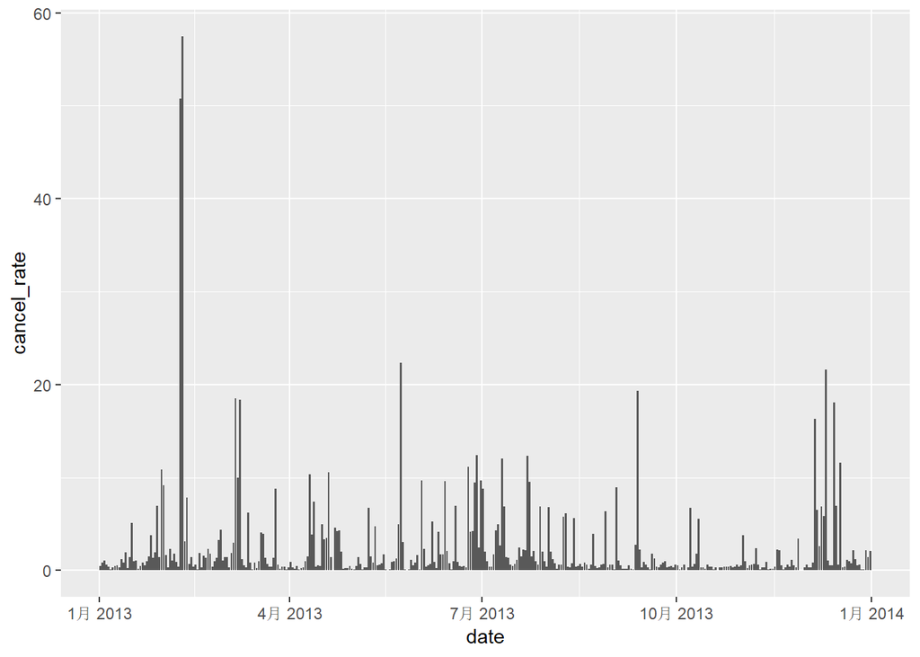

```r
flights <- mutate(flights, date = ISOdate(year, month, day))

cancelled <- filter(
  flights,
  is.na(dep_delay),
  is.na(arr_delay))

cancelled_each_day <- cancelled %>%
  group_by(date) %>%
  summarise(n_cancelled = n())

all_each_day <- flights %>%
  group_by(date) %>%
  summarise(n_total = n())

cancel <- merge(cancelled_each_day, all_each_day, by = "date", sort = TRUE, all.y = TRUE)
cancel [is.na(cancel)] <- 0
cancel$cancel_rate =100*( cancel$ n_cancelled / cancel$n_total)
ggplot(cancel, aes(x=date, y=cancel_rate)) +
    geom_bar(stat="identity")
```

6. According to the table below, we can see that flights to CAE is the worst and to LEX is the best.

```r
flights %>%
  group_by(dest) %>%
  summarize(mean_arrdelay = mean(arr_delay, na.rm = TRUE)) %>%
  mutate(rank_arrdelay = min_rank(-mean_arrdelay)) %>%
  arrange(rank_arrdelay)
```

```
## # A tibble: 105 x 3
##    dest  mean_arrdelay rank_arrdelay
##    <chr>         <dbl>         <int>
##  1 CAE            41.8             1
##  2 TUL            33.7             2
##  3 OKC            30.6             3
##  4 JAC            28.1             4
##  5 TYS            24.1             5
##  6 MSN            20.2             6
##  7 RIC            20.1             7
##  8 CAK            19.7             8
##  9 DSM            19.0             9
## 10 GRR            18.2            10
## # ... with 95 more rows
```

## 1.2 Transformations: Grouped operations with mutate() (and filter())

1. N179JB has the most minutes of delay total. That’s 4449 minutes in total.

```r
flights <- nycflights13::flights
t_delay <-
  flights %>%
  group_by(tailnum) %>%
  summarise(t_delay_minutes=sum(arr_delay))
(r_t_delay<-arrange(t_delay,desc(t_delay_minutes)))
```

```
## # A tibble: 4,044 x 2
##    tailnum t_delay_minutes
##    <chr>             <dbl>
##  1 N179JB             4449
##  2 N914XJ             3152
##  3 N598JB             3034
##  4 N629JB             2620
##  5 N203FR             2424
##  6 N826UA             2347
##  7 N502UA             2199
##  8 N648JB             2198
##  9 N591JB             2172
## 10 N433UA             1941
## # ... with 4,034 more rows
```

2. In order to avoid delays as much as possible, we should choose 7:00-8:00am to fly.(Because there is only one flight departs in 1:00-2:00am, we’d better not choose this time period.)

```r
f_dep <-
  flights %>%
  group_by(hour) %>%
  summarize(f_num = n(), p_delay = sum(arr_delay > 0, na.rm = TRUE) / f_num)
arrange(f_dep, p_delay)
```

```
## # A tibble: 20 x 3
##     hour f_num p_delay
##    <dbl> <int>   <dbl>
##  1     1     1   0
##  2     7 22821   0.268
##  3     5  1953   0.288
##  4     6 25951   0.288
##  5     8 27242   0.323
##  6     9 20312   0.332
##  7    11 16033   0.341
##  8    10 16708   0.347
##  9    12 18181   0.372
## 10    13 19956   0.403
## 11    14 21706   0.415
## 12    16 23002   0.441
## 13    15 23888   0.458
## 14    19 21441   0.468
## 15    18 21783   0.470
## 16    17 24426   0.474
## 17    22  2639   0.476
## 18    20 16739   0.478
## 19    21 10933   0.504
## 20    23  1061   0.511
```

3. The following is all the destinations that are ﬂown by at least two carriers.

```r
flights %>%
  group_by(dest) %>%
  filter(n_distinct(carrier) >= 2) %>%
  summarise()
```

```
## # A tibble: 76 x 1
##    dest
##    <chr>
##  1 ATL
##  2 AUS
##  3 AVL
##  4 BDL
##  5 BGR
##  6 BNA
##  7 BOS
##  8 BQN
##  9 BTV
## 10 BUF
## # ... with 66 more rows
```

```r
#a
f_gby <-
  flights %>%
  arrange(origin, dest, month, day, sched_dep_time) %>%
  group_by(origin, month, day)

f_lag <- f_gby %>%
  mutate(dif_delay = dep_delay - lag(dep_delay), na.rm = TRUE) %>%
  select(dif_delay, everything())

f_lag
```

```
## # A tibble: 336,776 x 21
## # Groups:   origin, month, day [1,095]
##    dif_delay  year month   day dep_time sched_dep_time dep_delay arr_time
##        <dbl> <int> <int> <int>    <int>          <int>     <dbl>    <int>
##  1        NA  2013     1     1     1315           1317        -2     1413
##  2        36  2013     1     1     1655           1621        34     1804
##  3        18  2013     1     1     2056           2004        52     2156
##  4        NA  2013     1     2     1332           1327         5     1419
##  5        80  2013     1     2     1746           1621        85     1835
##  6        19  2013     1     2     2148           2004       104     2234
##  7        NA  2013     1     3     1716           1619        57     1803
##  8       -64  2013     1     3     2031           2038        -7     2131
##  9        NA  2013     1     4     1618           1619        -1     1714
## 10        32  2013     1     4     2031           2000        31     2131
## # ... with 336,766 more rows, and 13 more variables: sched_arr_time <int>,
## #   arr_delay <dbl>, carrier <chr>, flight <int>, tailnum <chr>,
## #   origin <chr>, dest <chr>, air_time <dbl>, distance <dbl>, hour <dbl>,
## #   minute <dbl>, time_hour <dttm>, na.rm <lgl>
```

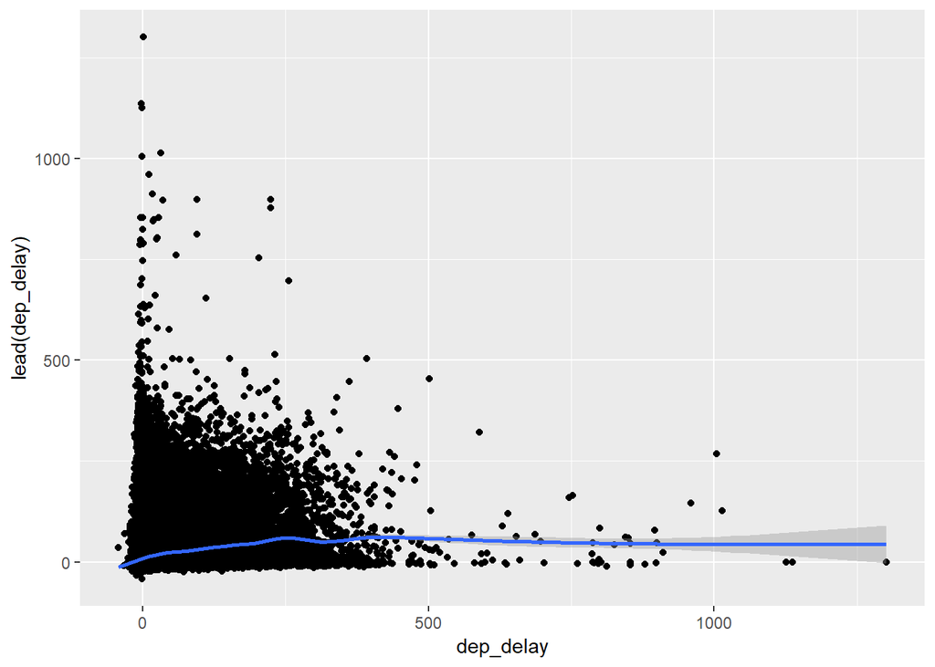

```r
# b
f_gby%>%ggplot(aes(x = dep_delay, y = lead(dep_delay))) +
  geom_jitter() +
  geom_smooth()
```

1. N703TW, N593JB, N578UA and N5DBAA were the most delayed in the air.
2. Flights like N956DL, N947UW, N12567 are suspiciously fast because the probablities of air time being short like this is less than 1e-19.

```r
#a
dif_median <-
  flights %>%
  group_by(tailnum, dest) %>%
  mutate(dif_median = air_time - median(air_time), na.rm = TRUE)
dif_median %>% select(dif_median, tailnum, everything()) %>% arrange(desc(dif_median))
```

```
## # A tibble: 336,776 x 21
## # Groups:   tailnum, dest [44,465]
##    dif_median tailnum  year month   day dep_time sched_dep_time dep_delay
##         <dbl> <chr>   <int> <int> <int>    <int>          <int>     <dbl>
##  1      146   N703TW   2013     7    28     1727           1730        -3
##  2      111   N593JB   2013    12    20     2052           2045         7
##  3      108   N578UA   2013     9    10     1513           1507         6
##  4      106   N5DBAA   2013     1    28     1806           1700        66
##  5       98   N328JB   2013     6    29      755            800        -5
##  6       97.5 N794JB   2013    12     7     1646           1620        26
##  7       94.5 N309JB   2013     2    11     1149           1155        -6
##  8       94   N16149   2013     1    15     1957           1935        22
##  9       94   N192DN   2013     7    10     1814           1815        -1
## 10       90   N466UA   2013     2    11     1248           1251        -3
## # ... with 336,766 more rows, and 13 more variables: arr_time <int>,
## #   sched_arr_time <int>, arr_delay <dbl>, carrier <chr>, flight <int>,
## #   origin <chr>, dest <chr>, air_time <dbl>, distance <dbl>, hour <dbl>,
## #   minute <dbl>, time_hour <dttm>, na.rm <lgl>
```

```r
# b
flights %>%
  group_by(dest) %>%
  mutate(threshold = quantile(air_time, probs = 1e-19, na.rm = TRUE), air_med = median(air_time, na.rm = TRUE), dif_median = air_time - air_med) %>%
  filter(air_time < threshold) %>%
  select(dif_median, tailnum, air_time, air_med, everything())
```

```
## # A tibble: 6 x 22
## # Groups:   dest [6]
##   dif_median tailnum air_time air_med  year month   day dep_time
##        <dbl> <chr>      <dbl>   <dbl> <int> <int> <int>    <int>
## 1        -39 N956DL       105     144  2013     1    12     1559
## 2        -17 N947UW        21      38  2013     3     2     1450
## 3        -43 N12567        70     113  2013     3    23     1914
## 4        -47 N666DN        65     112  2013     5    25     1709
## 5        -56 N17196        93     149  2013     7     2     1558
## 6        -33 N11544        62      95  2013     9    29     1359
## # ... with 14 more variables: sched_dep_time <int>, dep_delay <dbl>,
## #   arr_time <int>, sched_arr_time <int>, arr_delay <dbl>, carrier <chr>,
## #   flight <int>, origin <chr>, dest <chr>, distance <dbl>, hour <dbl>,
## #   minute <dbl>, time_hour <dttm>, threshold <dbl>
```

6. The variable before_1st displays the number of ﬂights before the ﬁrst delay of greater than 1 hour.

```r
flights %>%
  group_by(year, month, day) %>%
  arrange(dep_time) %>%
  mutate(delay1h = if_else(arr_delay > 60, 1, 0),
         first_delay1h = cumsum(delay1h),
         before_1st = sum(first_delay1h == 0, na.rm = TRUE)) %>%
  select(before_1st, everything())
```

```
## # A tibble: 336,776 x 22
## # Groups:   year, month, day [365]
##    before_1st  year month   day dep_time sched_dep_time dep_delay arr_time
##         <int> <int> <int> <int>    <int>          <int>     <dbl>    <int>
##  1          0  2013     1    13        1           2249        72      108
##  2          0  2013     1    31        1           2100       181      124
##  3        148  2013    11    13        1           2359         2      442
##  4          1  2013    12    16        1           2359         2      447
##  5        146  2013    12    20        1           2359         2      430
##  6        112  2013    12    26        1           2359         2      437
##  7          3  2013    12    30        1           2359         2      441
##  8          0  2013     2    11        1           2100       181      111
##  9          0  2013     2    24        1           2245        76      121
## 10          1  2013     3     8        1           2355         6      431
## # ... with 336,766 more rows, and 14 more variables: sched_arr_time <int>,
## #   arr_delay <dbl>, carrier <chr>, flight <int>, tailnum <chr>,
## #   origin <chr>, dest <chr>, air_time <dbl>, distance <dbl>, hour <dbl>,
## #   minute <dbl>, time_hour <dttm>, delay1h <dbl>, first_delay1h <dbl>
```

## 1.3 Exploratory Data Analysis

### 1.3.1 EDA: Exploring variation

1. With the prices are higher, there are less number of diamonds sold, which makes sense to me, because higher price is less affordable. Moreover, there’s no diamonds cost less than around 250 dollars, since the diamond itself is valuable.

What surprises me is that there’s a threshold at 1500 dollars. Probably there’s strict regulation of 1500 dollars to identify the high-end and valued types of diamonds.

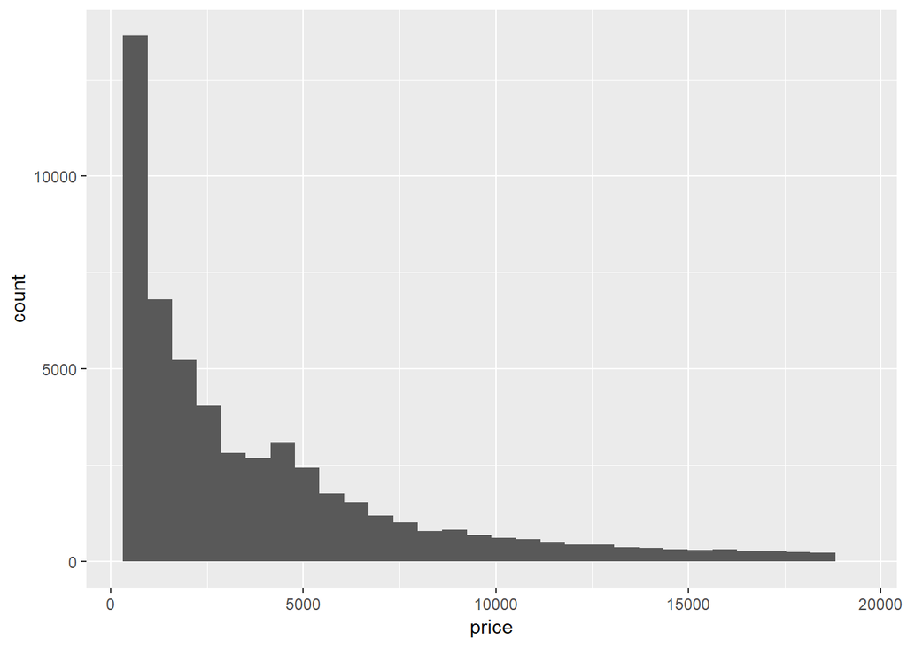

```r
ggplot(diamonds, aes(x = price)) +
  geom_histogram()
```

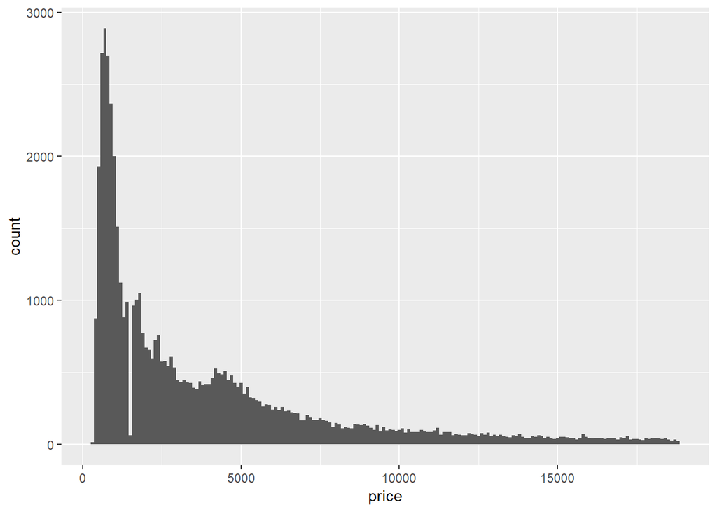

```r
ggplot(diamonds, aes(x = price)) +
  geom_histogram(binwidth=100)
```

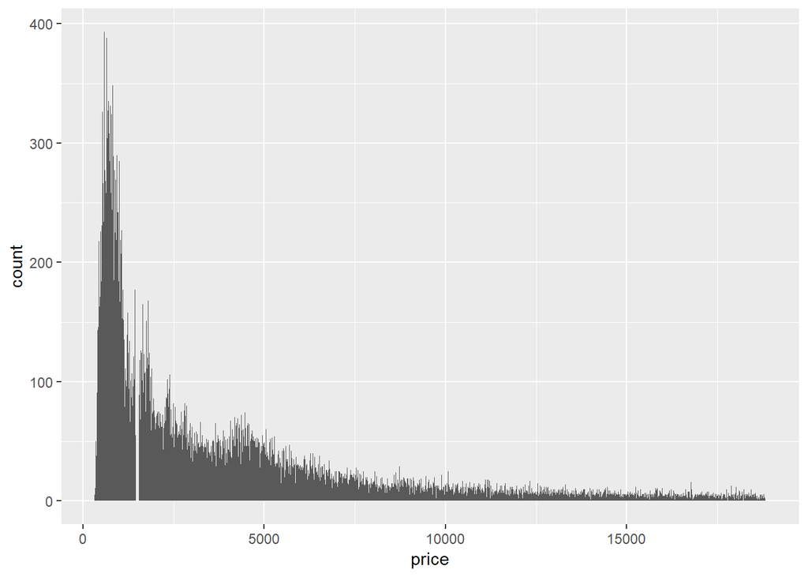

```r
ggplot(diamonds, aes(x = price)) +
  geom_histogram(binwidth=10)
```

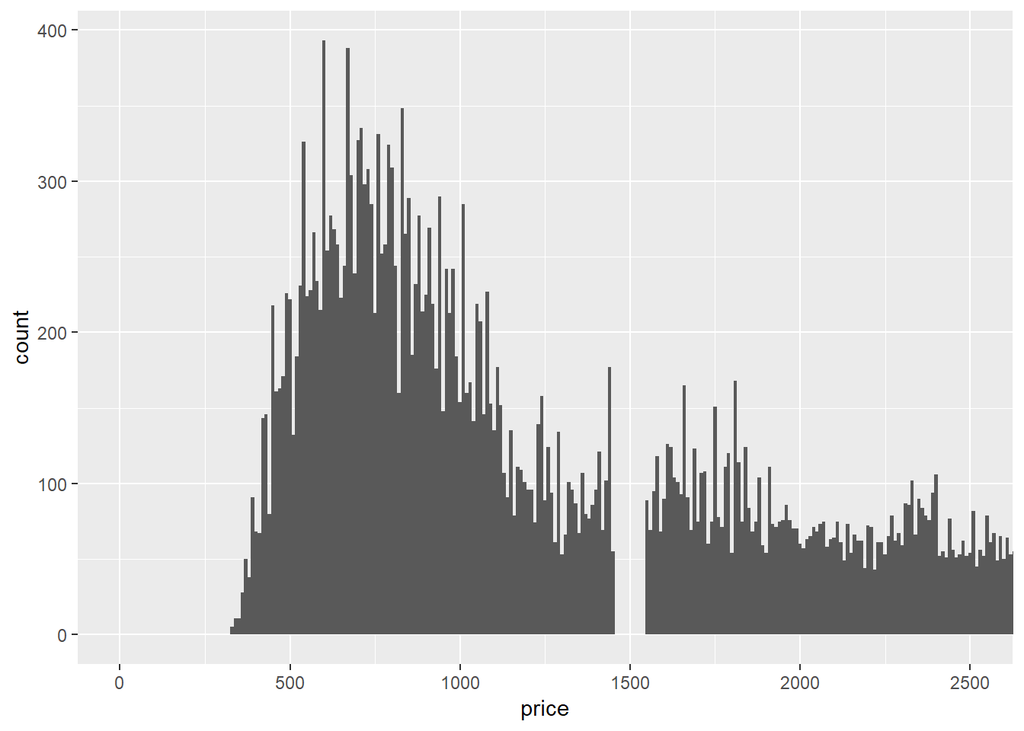

```r
ggplot(diamonds, aes(price)) +
  geom_histogram(binwidth = 10) +
  coord_cartesian(xlim = c(0,2500))
```

2. There are many discontinuities for certain amounts of carat. Especially when the smaller the diamond, the more discontinuities in carat.

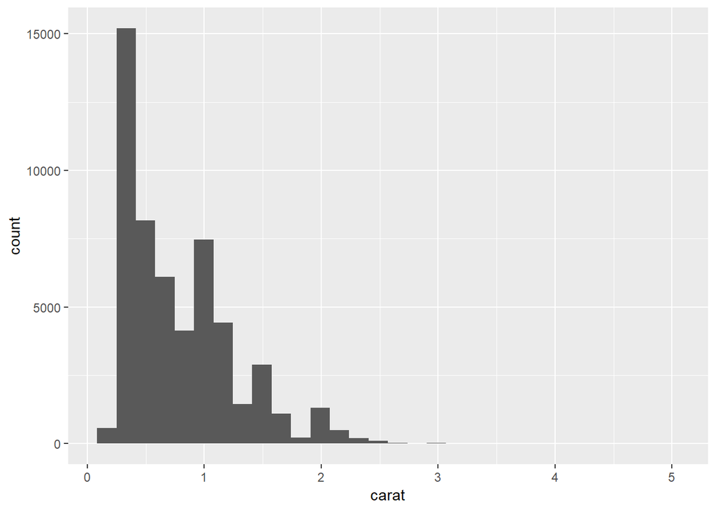

```r
ggplot(diamonds, aes(carat)) +
  geom_histogram()
```

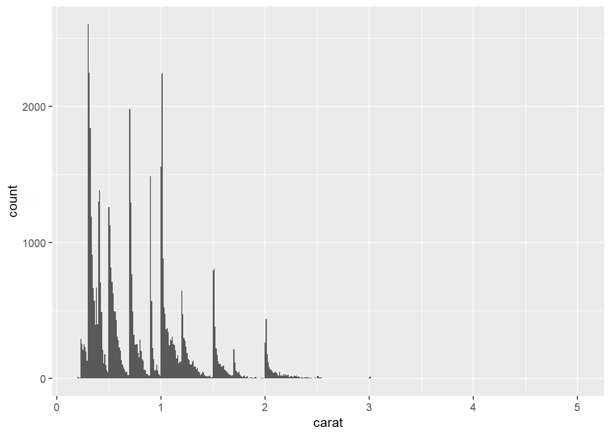

```r
ggplot(diamonds, aes(carat)) +
  geom_histogram(binwidth = .01)
```

```r
count(filter(diamonds, carat==.99 | carat==1), carat)
```

```
## # A tibble: 2 x 2
##   carat     n
##   <dbl> <int>
## 1  0.99    23
## 2  1     1558
```

3. When using xlim and ylim, some observations are removed, and the binwidth will adjust automatically; however, coord_cartesian can gives us full information. By setting binwidth, the graph is more informative and detailed.

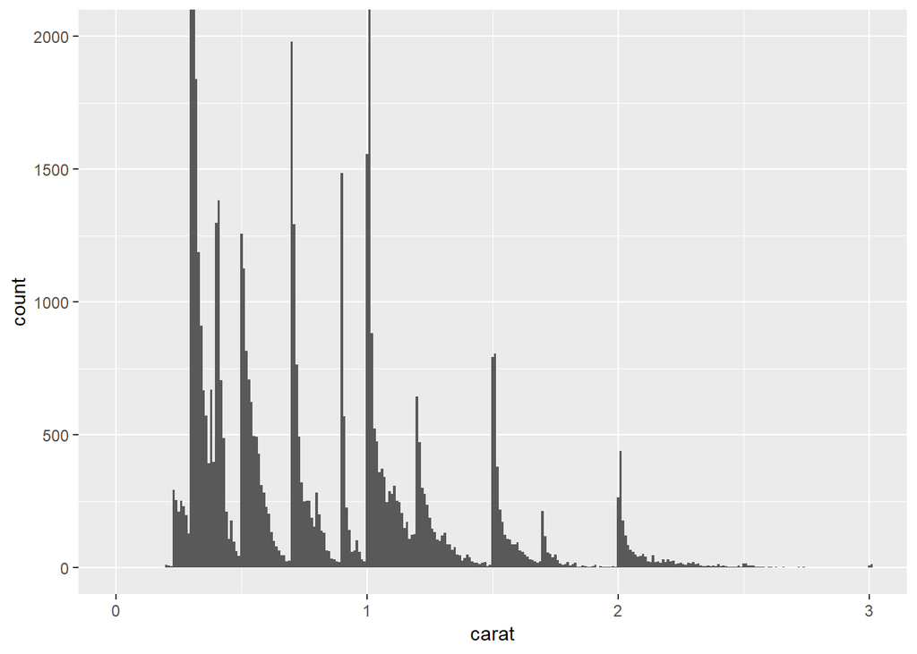

```r
ggplot(diamonds, aes(carat)) +
  geom_histogram(binwidth = .01) +
  coord_cartesian(xlim = c(0,3), ylim = c(0,2000))
```

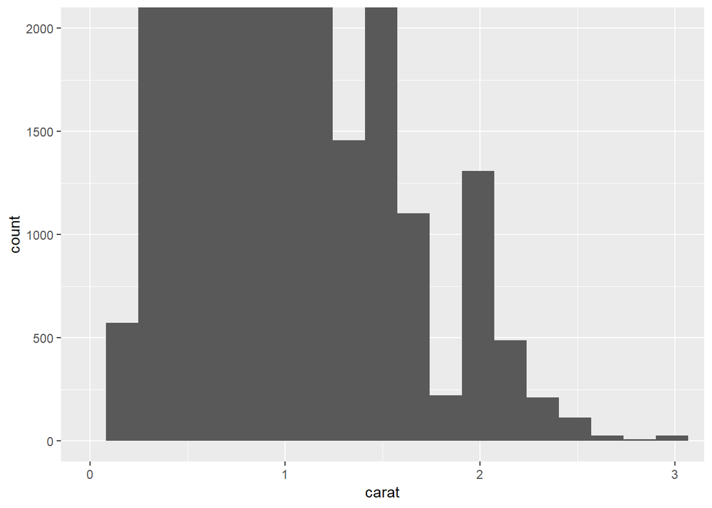

```r
ggplot(diamonds, aes(carat)) +
  geom_histogram() +
  coord_cartesian(xlim = c(0,3), ylim = c(0,2000))
```

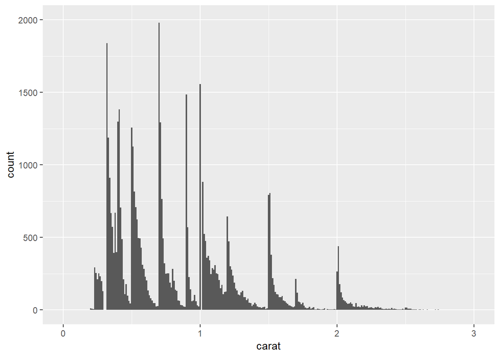

```r
ggplot(diamonds, aes(carat)) +
  geom_histogram(binwidth = .01) +
  xlim(0,3) +
  ylim(0,2000)
```

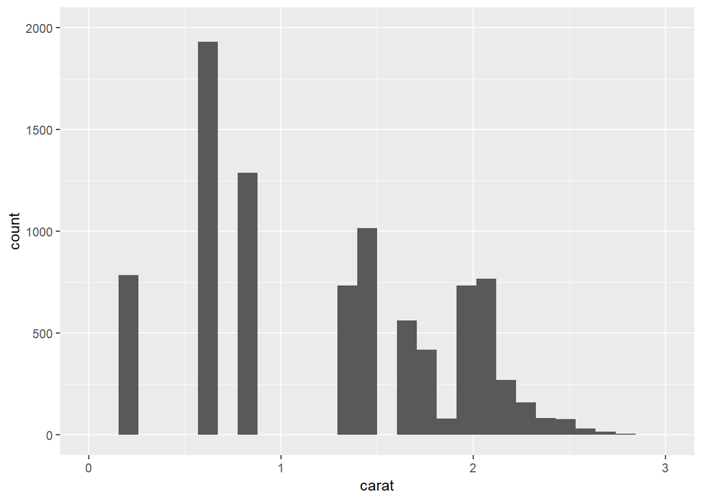

```r
ggplot(diamonds, aes(carat)) +
  geom_histogram() +
  xlim(0,3) +
  ylim(0,2000)
```

### 1.3.2 EDA: Navigating NAs

1. Missing values are dropped in a histogram. In bar chart, missing values are included in a discrete category. There is a difference because “x” argument needs to be continuous, numeric values in a histogram so that observations can be grouped into bins while “x” can be categorical in a bar chart.
2. na.rm = TRUE removes “NA” values from the observations that mean() and sum() are going to make calculation on so that mean() and sum() can calculate the values of variables without “NA”.

# 2 Public Sector Application: When should they Mayor’s tourism office host their convention

READ BTS Data

```r
ILflights <- read.csv("D:\\R\\dataset\\ILflights.csv")

# flights to chicago

CHIflights <- ILflights %>% filter(DEST_CITY_NAME == "Chicago, IL")
```

## 2.1 Choose a month

1. According to the plot, we can see that the average delays in October is the lowest, with an average of 9-minute delay. Every month except July, August and December, are at least 80% of flights on-time.

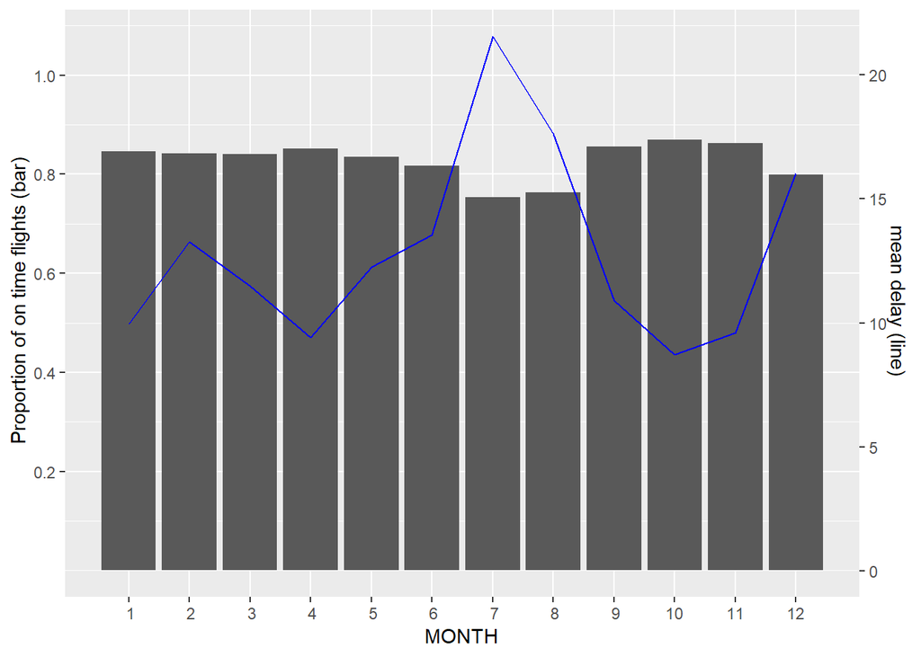

```r
gby_month <- CHIflights %>% group_by(MONTH)

arrdelays <-
  gby_month %>%
  summarise(avg_arrdelay       = mean(ARR_DELAY, na.rm = TRUE),
            avg_arrdelay_new   = mean(ARR_DELAY_NEW, na.rm = TRUE),
            prop_ontime        = 1-sum(ARR_DEL15,na.rm = TRUE)/n(),
            n_flights = n()
  )

ggplot(arrdelays, aes(x = MONTH)) +
  geom_col(aes(y = prop_ontime)) +
  geom_line(aes(y = avg_arrdelay_new/20), color ="blue") +
  scale_x_discrete(limits=c(1:12)) +
  scale_y_continuous(breaks   = c(.2, .4, .6, .8, 1),
                     sec.axis = sec_axis(~.*20,
                     name     = "mean delay (line) "
                    )) +
  labs(y = " Proportion of on time flights (bar)")
```

2. Flights to Chicago are most common in July. In July, there are above 30000 flights that fly to Chicago.

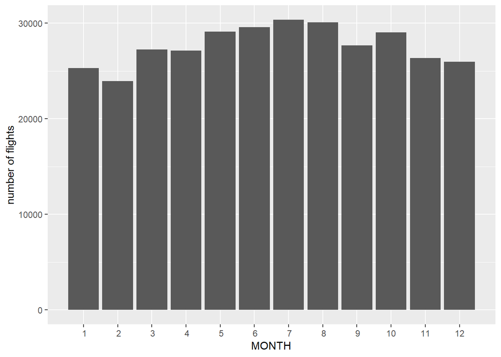

```r
sum_month <-
  gby_month %>%
  summarise(n_chi_flights = sum(DEST_CITY_NAME == "Chicago, IL", na.rm = TRUE))

ggplot(sum_month, mapping = aes(x = MONTH, y = n_chi_flights)) +
  geom_col() +
  scale_x_discrete(limits = c(1:12)) +
  labs(y="number of flights")
```

3. I recommend the October because the average arrival delay is the lowest and the proportion of on time flights is highest in October.

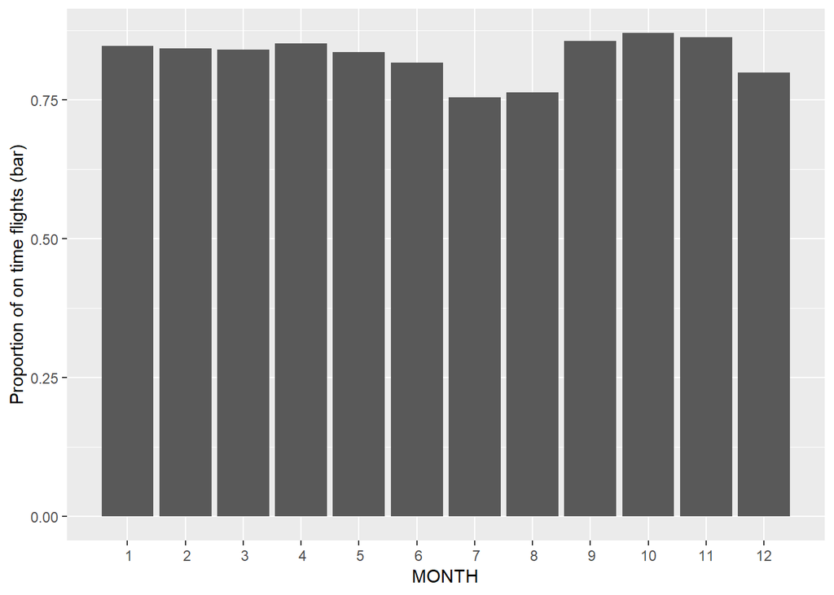

```r
# basic
ggplot(arrdelays, aes(x = MONTH)) +
  geom_col(aes(y = prop_ontime)) +
  scale_x_discrete(limits = c(1:12)) +
  labs(y = "Proportion of on time flights (bar)")
```

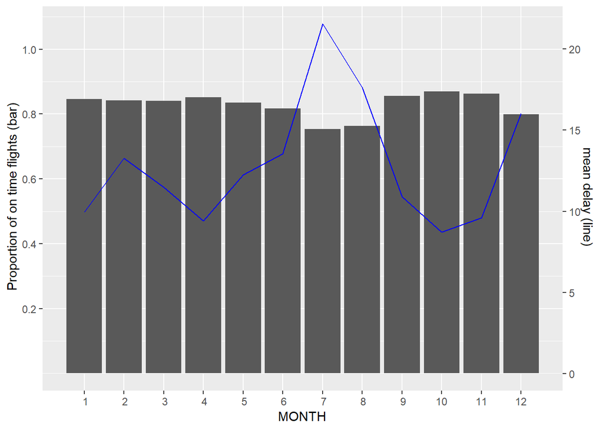

```r
# sophisticated

ggplot(arrdelays, aes(x = MONTH)) +
  geom_col(aes(y = prop_ontime)) +
  geom_line(aes(y = avg_arrdelay_new / 20), color = "blue") +
  scale_x_discrete(limits = c(1:12)) +
  scale_y_continuous(
    breaks = c(.2, .4, .6, .8, 1),
    sec.axis = sec_axis(~. * 20,
      name = "mean delay (line) "
    )
  ) +
  labs(y = " Proportion of on time flights (bar)")
```

## 2.2 Pick an airline

1. I would recommend AS. Because the probablity of an AS flight to be late is the lowest and the mean delay time of an AS flight is shortest. In addition, even an AS flights is late, the delay is unlikely to be extremly long and is usually within 350 minutes, making the situation more controlable.

I prefer the sophisticated one because it gives more information about the airline such as the dispersion of the delay and makes us have more confidence on the recommedation we make.

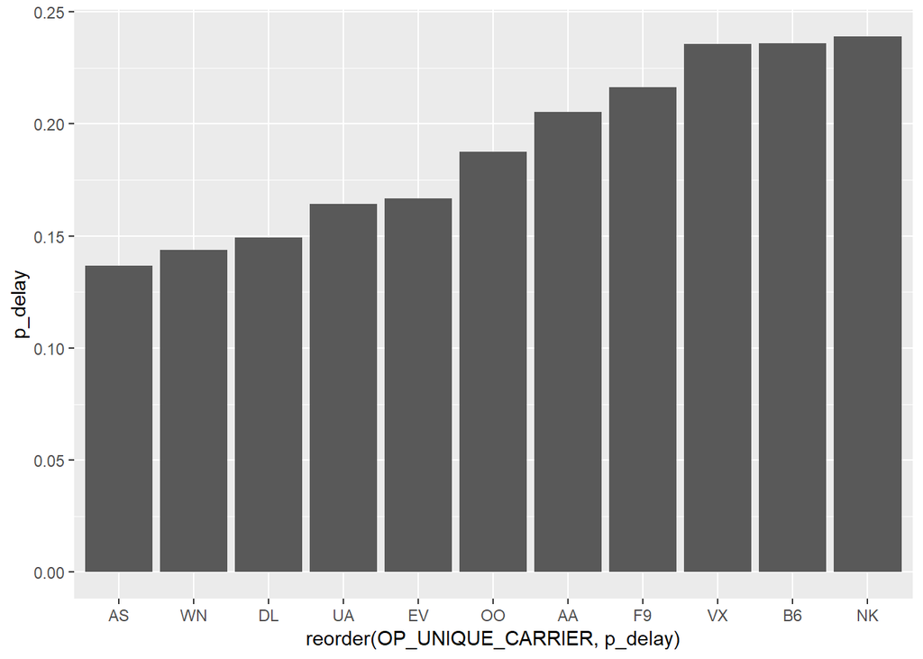

```r
gby_carr <-
  CHIflights %>%
  group_by(OP_UNIQUE_CARRIER)

sum_carr <-
  gby_carr %>%
  summarise(n_cflights = n(),
            n_delay = sum(ARR_DEL15, na.rm = TRUE),
            p_delay = n_delay / n_cflights,
            mean_delay = mean(ARR_DELAY_NEW, na.rm = TRUE),
            max_delay = max(ARR_DELAY_NEW, na.rm = TRUE))

# basic
sum_carr %>%
  ggplot() + geom_col(mapping = aes(x = reorder(OP_UNIQUE_CARRIER, p_delay), y = p_delay))
```

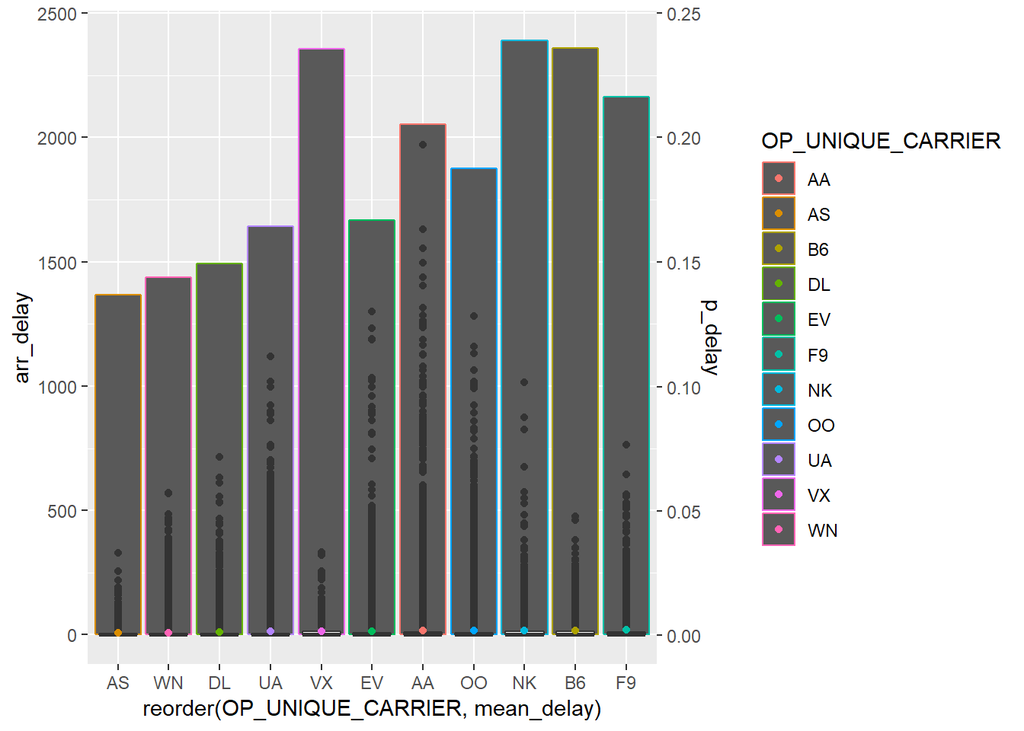

```r
# sophisticated
graph_sop <-
  ggplot(sum_carr) +
  geom_col(mapping = aes(
    x = reorder(OP_UNIQUE_CARRIER, mean_delay),
    y = p_delay * 10000,
    color = OP_UNIQUE_CARRIER
  )) +
  geom_boxplot(
    data = gby_carr,
    mapping = aes(x = OP_UNIQUE_CARRIER, y = ARR_DELAY_NEW)
  ) +
  geom_point(aes(
    x = OP_UNIQUE_CARRIER,
    y = mean_delay,
    color = OP_UNIQUE_CARRIER
  )) +
  scale_y_continuous(sec.axis = sec_axis(trans = ~. / 10000, name = "p_delay")) +
  labs(y = "arr_delay")
graph_sop
```

## 2.3 Reconsider the date?

1. New recommendation would be November. Because in November, the average arrival delay of flights from Greer and that of all the flights to Chicago are rather low.In addtion, the proportion of on time flights from Greer and that of all the flights to Chicago are also relatively higher.

It is superior to the old recommedarion because new ranking factors have been taken into consideration and the needs of most important members and the rest of participants are balanced in the new recommendation.

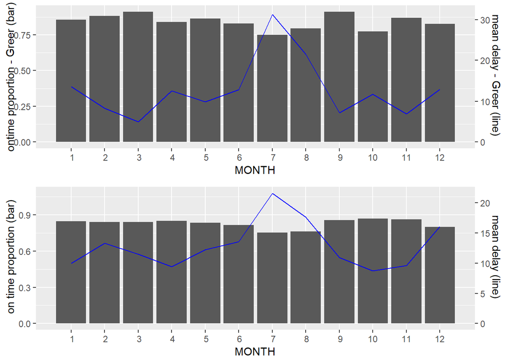

```r
gre_flights <-
  CHIflights %>%
  filter(ORIGIN_CITY_NAME=="Greer, SC") %>%
  group_by(MONTH)

gre_delays <-
  gre_flights %>%
  summarise(gre_mean_delay = mean(ARR_DELAY_NEW, na.rm = TRUE),
            prop_ontime    = 1-sum(ARR_DEL15,na.rm = TRUE)/n(),
            )

graph_gre <-
  ggplot(gre_delays, aes(x = MONTH)) +
  geom_col(aes(y = prop_ontime)) +
  geom_line(aes(y = gre_mean_delay/35), color ="blue") +
  scale_x_discrete(limits=c(1:12)) +
  scale_y_continuous(sec.axis = sec_axis(~.*35,
                     name     = "mean delay - Greer (line) "
                    )) +
  labs(y = "ontime proportion - Greer (bar)")

graph_whole <-
  ggplot(arrdelays, aes(x = MONTH)) +
  geom_col(aes(y = prop_ontime)) +
  geom_line(aes(y = avg_arrdelay_new/20), color ="blue") +
  scale_x_discrete(limits=c(1:12)) +
  scale_y_continuous(sec.axis = sec_axis(~.*20,
                     name     = "mean delay (line) "
                    )) +
  labs(y = " on time proportion (bar)")

library(grid)

grid.newpage()
grid.draw(rbind(ggplotGrob(graph_gre), ggplotGrob(graph_whole), size = "last"))
```

```r
#https://gist.github.com/tomhopper/faa24797bb44addeba79
```